# Exploring the Influence of Lifestyle Factors on Obesity Prevelance in Scotland

# 1 Introduction

Time and time again in the UK we see obesity putting more people’s lives at risk and more pressure on the NHS. Not only does obesity cause majority health complications but it also puts strain on the NHS’s already dwindling budget. So the question arises, is our government doing enough to combat this epidemic?

There is no one solution to cure obesity as many different socio-economic factors play a role in a person’s diet and lifestyle. In the following report we shall investigate the change in the prevalence of obesity in Scotland from 2008-2012, as well as determining if obesity rates are influenced by ages, gender, socio-economic status or other lifestyle factor.

We shall conduct a brief exploratory analysis in Section 2 followed by more rigorous analysis in Section 3 and with concluding remarks in Section 4.

# 2 Exploratory Analysis

First, we created a new indicator covariate “Obese” according to the original variable “BMIgroup”. As we can see, it was a categorical response variable with four different levels. Our aim was to explore the impact of different factors on obesity, so we use 1 and 0 to separate obese people and other type of people.

Second, we calculated the value of obesity number by year and found each year the population sizes were different. In order to avoid the influence of population size, we calculated the proportion of prevalence of obesity over year and drew a time series plot of obese observations from 2008 to 2012 to show whether the proportion of prevalence of obesity in Scotland changed over the years.

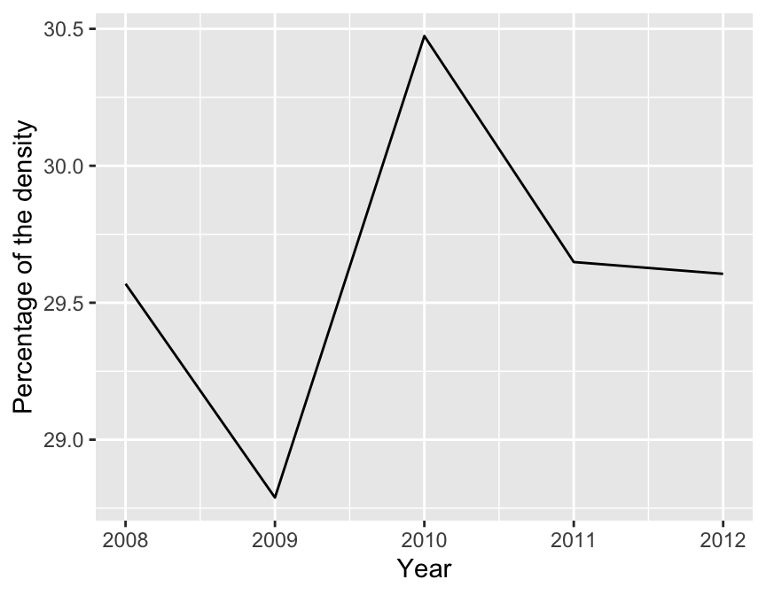

Figure 1: Time Series Plot of Obese Observations Over Time.

From Figure 1 , we could see that the obesity prevalence proportion first decreased from 2008 to 2009 and got the lowest value 28.78%. Then it increased dramatically and reached its peak value, 30.47% , in 2010. After 2010, it kept decreasing and it got 29.61% in 2012.

Table 1: Obese Counts Per Year

| Year | Count_Obese |
| --- | --- |
| 2008 | 1448 |
| 2009 | 1647 |
| 2010 | 1666 |
| 2011 | 1620 |
| 2012 | 1088 |

From Table 1 we see the overall counts of obese observations per year. Again this is helpful to visualise the obese observations however, as stated above, proportions were preferred for this study as it was not balanced.

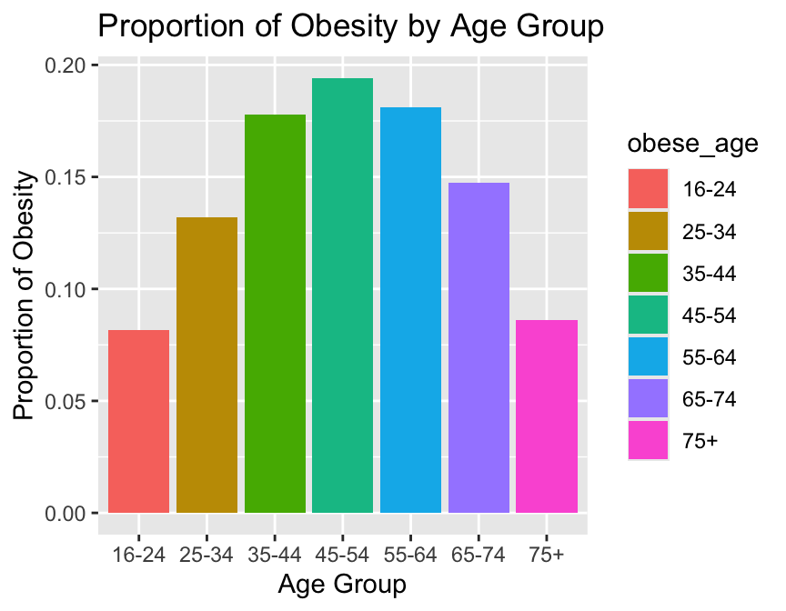

Figure 2: Proportion of obesity by age groups.

Figure 2 displayed the proportion of obesity over each age group. 45-54 group occupied the highest proportion which was nearly 20% . 16-24 and 75+ groups shared the similar proportion which was approximately 8%. We can also see that the proportions per age appear to be normally distributed centred around 45-54 years of age suggesting those who are middle aged are more likely to be obese compared to their younger and older counter parts.

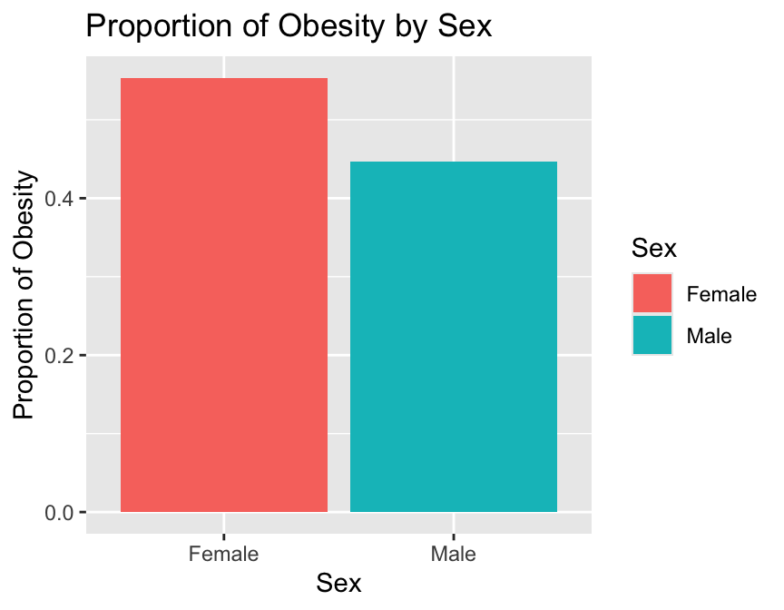

Figure 3: Proportion of Obesity by Sex.

Figure 3 displays the proportion of obesity by sex. Females occupied a higher proportion of obesity which was nearly 55% . Whereas males occupied a lower proportion of obesity which was nearly 45%.

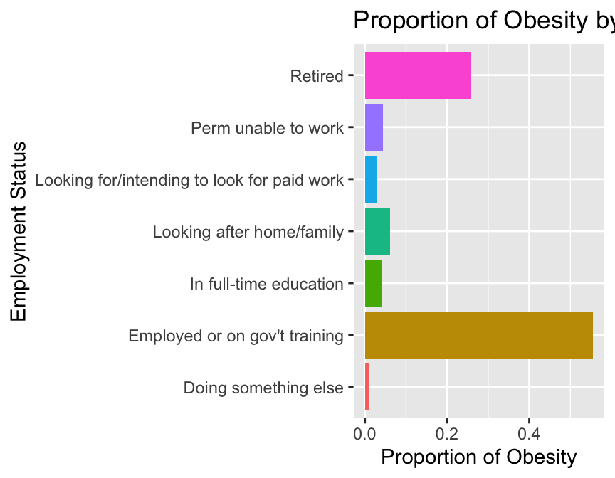

Figure 4: Proportion of Obesity by Employment status.

Figure 4 displays the proportion of obesity over each socio-economic status. The most obese socio-economic group was “In paid employment, self-employed or on gov’t training” which was occupied by the highest proportion of obese observations, which was nearly 55.55% . Whereas “Doing something else” had the lowest proportion of obese observations which was approximately 1%.

# 3 Formal Analysis

After conducting some exploratory analysis to help us visualise the data in Section 2, we now conduct some more rigorous analysis by fitting a series of logistic regression models.

We first fit a model that took into account all predictor variables and interaction terms. After following a process of backwards elimination we determined that the interaction terms were not significant and by following the Principle of Occam’s Razor, we proceeded to fit the most simple model.

## 3.1 Obesity by Sex

Table 2: Regression output for obesity by sex

| term | estimate | p-value |
| --- | --- | --- |
| intercept | -0.85652 | <2e-16 *** |
| SexMale | -0.02106 | 0.448 |

From the regression output in Table 2 we get the following regression equation

$$\mbox{ln}({\frac{p}{1-p}}) = \alpha + \beta \cdot\mbox{Sex}= -0.86 -0.02 \cdot \mathbb{I}_{\mbox{Sex}}(\mbox{Male})$$

From our regression output we can also determine the probability that someone is obese given that they are male and then the probability that someone is obese given that they are female which is determined to be the following:

Table 3: Probability of obesity by sex

[output not shown]

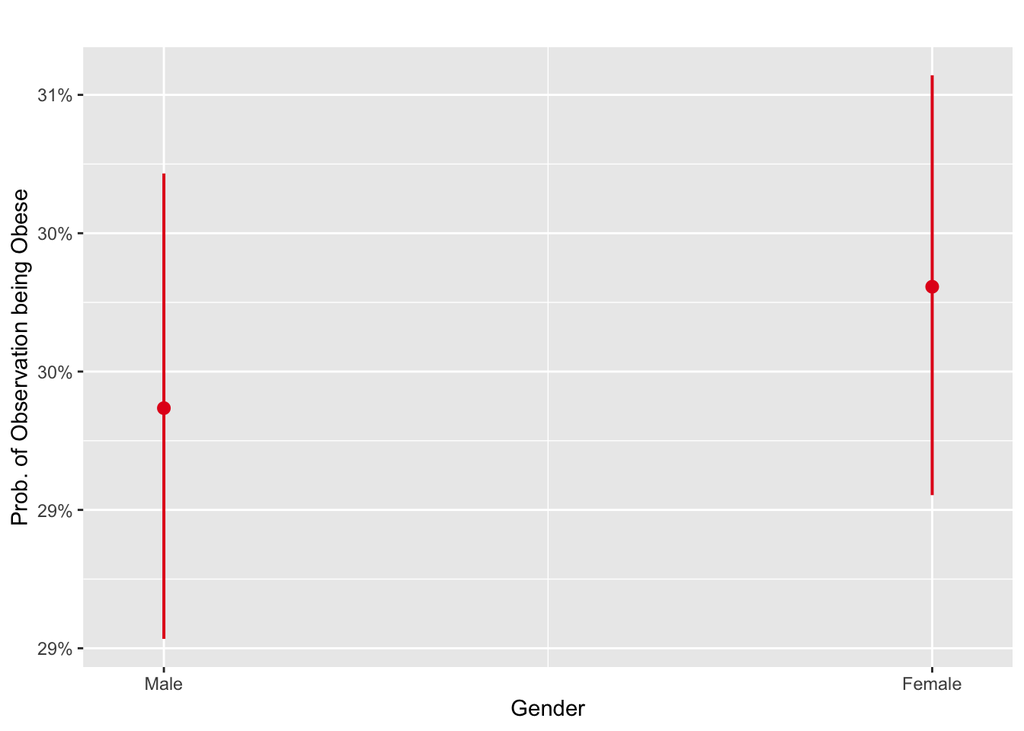

Figure 5: Confidence Interval Plot for Sex

From these two values in Table 3 we see that there is not much of a difference between probability that someone is obese given they are male compared to the probability that someone is obese given they are female. This coincides with the regression output in Table 2 as the p-value for males is not statistically significant. We are inclined to believe that gender is not an influential factor on obesity.

We also see that the difference in the null and residual deviance for the sex model is 1 and and this is smaller than the 95th percentile of a chi-squared distribution on 1 degree of freedom which is 3.84. Therefore it is not worth including sex in the model.

## 3.2 Obesity by Age

Table 4: Regression output of obesity by age group

| term | estimate | p-value |
| --- | --- | --- |
| Intercept | -1.73631 | <2e-16 *** |
| 25-34 | 0.44453 | 2.68e-09 *** |
| 35-44 | 0.88317 | <2e-16 *** |
| 45-54 | 0.95485 | <2e-16 *** |
| 55-64 | 1.16308 | <2e-16 *** |
| 65-74 | 1.11899 | <2e-16 *** |
| 75+ | 0.81453 | <2e-16 *** |

The difference in the null and residual deviance for the age model is 499 and this is much larger than the 95th percentile of a chi-squared distribution on 6 degrees of freedom which is 12.59. Therefore it is worth including age in the model.

The baseline category for the binary response is not obese and the baseline category for age is 16-24. This means that estimates from the logistic regression model are for a change on the log-odds scale for being obese in comparison to the response baseline of not obese and for all other age groups in comparison to age group 16-24.

The model equation from Table 4 is

$$\mbox{ln}({\frac{p}{1-p}}) = \alpha + \beta \cdot\mbox{Age Group}= -1.73 + 0.44 \cdot \mathbb{I}_{\mbox{Age Group}}(\mbox{25-34}) + 0.88 \cdot \mathbb{I}_{\mbox{Age Group}}(\mbox{35-44}) + 0.95 \cdot \mathbb{I}_{\mbox{Age Group}}(\mbox{45-54}) + 1.16 \cdot \mathbb{I}_{\mbox{Age Group}}(\mbox{55-64})+ 1.11 \cdot \mathbb{I}_{\mbox{Age Group}}(\mbox{65-74}) + 0.81 \cdot \mathbb{I}_{\mbox{Age Group}}(\mbox{75+})$$

where $\mathbb{I}_{\mbox{Age Group}}$ is an indicator function For example the log odds increase of being obese increase by 0.44 for people in the 25-34 age group.

The probabilities of being obese for each age group starting at age group 16-24 are

Table 5: Probability of Obesity by Age Group

| Age Group | Probability |
| --- | --- |
| 16-24 | 0.1498 |
| 25-34 | 0.2156 |
| 35-44 | 0.2989 |
| 45-54 | 0.3140 |
| 55-64 | 0.3605 |
| 64-75 | 0.3504 |
| 75+ | 0.2846 |

We can see from Table 5 the probability of being obese is highest for the 55-64 age group and lowest for the 16-24. We can plot the estimated probabilities by age group.

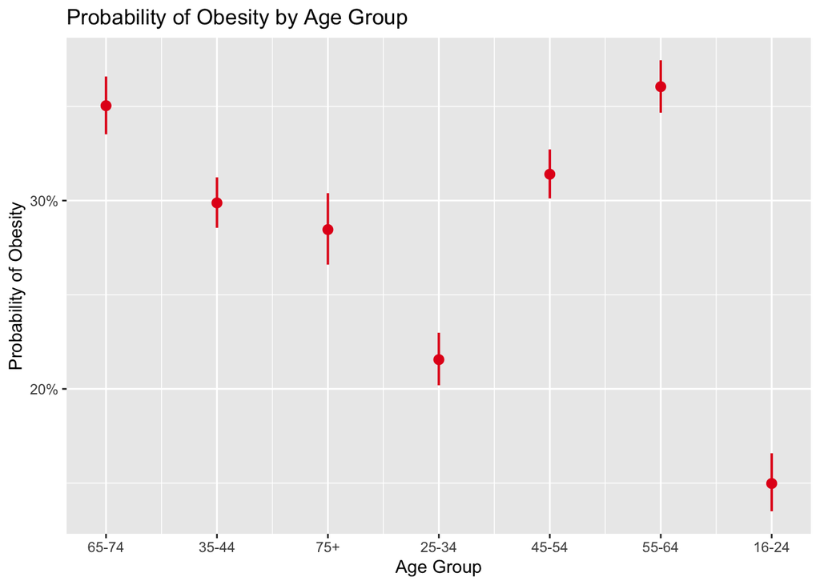

Figure 6: Confidence Interval Plot for Age Group

We can see from Figure 6 that there is quite a lot of difference between the estimated probabilities of being obese in each group.

## 3.3 Obesity by Employment Status

Table 6: Regression Output for Obesity by Employment Status

| term | estimate | p-value |
| --- | --- | --- |
| Intercept | -0.86824 | 5.45e-11 *** |
| In full time education | -1.16236 | 1.68e-12 *** |
| In paid employment, self employed or gov’t training | -0.03470 | 0.79521 |
| Looking after home/family | -0.06153 | 0.66875 |
| Looking for/ intending to look for paid work | -0.12037 | 0.43834 |
| Perm unable to work | 0.41501 | 0.00444 ** |
| Retired | 0.16511 | 0.22132 |

The difference in the null and residual deviance for the socio-economic status model is 277 and and this is larger than the 95th percentile of a chi-squared distribution on 6 degrees of freedom which is 12.59. Therefore it is worth including socio-economic status in the model.

For socio-economic status, from Table 6, we have the following model,

$$\mbox{ln}({\frac{p}{1-p}}) = \alpha + -1.16 \cdot \mathbb{I}_{\mbox{Edu}}(x) + -0.03 \cdot \mathbb{I}_{\mbox{Emp}}(x) + -0.06 \cdot
\mathbb{I}_{\mbox{Home}}(x) + -0.12 \cdot \mathbb{I}_{\mbox{LFW}}(x) + 0.42 \cdot \mathbb{I}_{\mbox{Unable}}(x) + 0.17 \cdot \mathbb{I}_{\mbox{Retired}}(x)$$

where $\mathbb{I}_{\mbox{Edu}}(x)$, $\mathbb{I}_{\mbox{Emp}}(x)$, $\mathbb{I}_{\mbox{Home}}(x)$, $\mathbb{I}_{\mbox{LFW}}(x)$, $\mathbb{I}_{\mbox{Unable}}(x)$, $\mathbb{I}_{\mbox{Retired}}(x)$ are indicator functions such that: ‘Edu’ represents subjects in full-time education, ‘Emp’ represents paid employment, self-employment or government training, ‘Home’ represents looking after home or family, ‘LFW’ represents looking for work, ‘Unable’ represents unable to work and ‘Retired’ represents subjects that are retired.

We again have that the baseline category for the binary response is ‘not obese’ and the baseline for employment status is ‘Doing Something Else’. This means we can interpret the estimates from the logistic regression as the change in the log-odds scale for ‘obese’ compared to the baseline ‘not obese’ and for all other employment status in comparison to ‘Doing Something Else’.

The probabilities of being obese for each socio-economic status are

Table 7: Probability of Obesity Given Employment Status

| Employment Status | Probability |
| --- | --- |
| Doing something else | 0.2956204 |
| In full time education | 0.1160275 |
| In paid employment, self employed or gov’t training | 0.2884464 |
| Looking after home/family | 0.2829706 |
| Looking for/ intending to look for paid work | 0.2711864 |
| Perm unable to work | 0.3885918 |
| Retired | 0.3311176 |

Table 7 shows that the probability of being obese is highest for subjects that are permanently unable to work, it is lowest for subjects in full-time education.

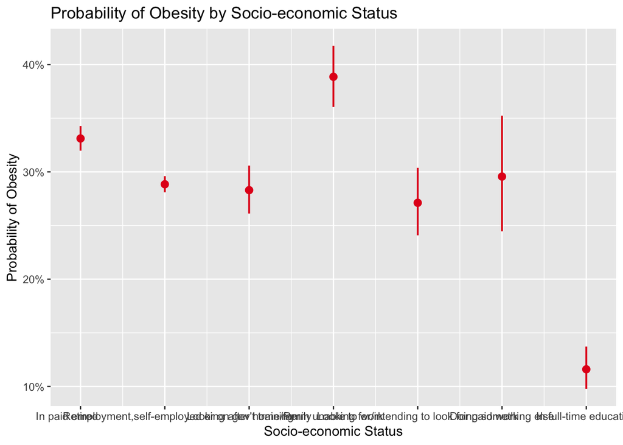

Figure 7: Confidence Interval Plot for Socio-Economic Status

From Figure 7 we can see there appears to be a significant difference in the probability of being obese between different socio-economic groups.

# 4 Conclusions

In our exploratory analysis in Section 2 we investigated trends in obesity over the time period of 2008-2012. We saw that obesity initially decreased but then sharply increased in 2010 before decreasing again over the following years.

From the formal analysis in Section 3 we see in our model considering the sex variable that sex is not a statistically significant predictor of obesity prevalence. Although the estimated probability of obesity appears to be slightly higher for females which is also what was found in exploratory analysis.

On the other hand, we found that age was statistically significant and was worth including in the model. The estimated probabilities by age group suggest that middle-aged people are more likely to be obese than both younger and older people, which is consistent with what initially appeared to be the case in our exploratory analysis.

Furthermore, we also found socio-economic status to be a statistically significant predictor of obesity with people in full-time education least likely to be obese and people that are permanently unable to work most likely to. These results are similar to the conclusions drawn in exploratory analysis however we initially found individuals in paid employment most likely and people ‘doing something else’ least likely to be obese.

Thus we conclude that there are differences in obesity prevalence by age and socio-economic status, but not by gender.

While our analysis provides insight into the effect of age and socio-economic status on obesity, several limitations are observed. The sample size may be considered unbalanced as the population sizes of each level in the categorical variable are not similar.

Furthermore, there maybe confounding variables which were not accounted for, such as additional socioeconomic factors, which may impact the results. Our analysis highlights the importance of age and socio-economic status as they have clear impact on the obesity prevalence , therefore more attention should be paid to 55-64 age group and “unable to work” group. Future studies should consider following the experimental population over a longer time period to see if there will be changes in the status of obesity.Finally, they should also consider utilizing a more balanced sample and control for additional confounding variables.